# dynamic time warping

Xinyu yao

2021/1/7

##Install package

```r
library(dtw)
library(lubridate)
library(dtwclust)
library(tidyverse)
library(dplyr)
library(zoo)
library(rlist)
library(rvest)
library(xml2)
library(httr)
library(stringr)
```

##Reading data into R

```r
dat2 <- read.csv("full_data.csv", header=T, na.strings=c("","NA"))
```

## Getting table from html page

```r
webpage <- "https://siccode.com/page/what-is-an-anzsic-code"
response <- GET(webpage)
table <- html_table(content(response))[2]
df <- as.data.frame(table)
```

```r
companies_type <- read.csv("companies.csv", header = TRUE)
companies_type <- companies_type[!(is.na(companies_type$industry) | companies_type$industry==""), ]
companies_type$industry <- as.character(companies_type$industry)
industry <- unique(companies_type$industry)
```

##pre-processing the table

```r
for(index in 1:length(df$X3)){
  if(df$X1[index] != ""){
    cur <- df$X1[index]
  }
  else{
    df$X1[index] = cur
  }
}
```

#Pick the key words

```r
a_list <- list()
for (element in unique(df$X1)){
  x <- c(gsub("[,()]","",unlist(strsplit(df[df$X1 == element,]$X3, " "))))
  a_list[[element]] <- unique(x[! x%in% c("and", "of", "for", "Services", "Other")])
}
```

```r
lst2 <- unique(strsplit(gsub("\\s+", " ", gsub("and|of|Services|Other,", " ", companies_type$industry), " "), " "))
```

```r
labels <- c("E", "C", "L", "G", "G", "K", "I", "unknown", "Q", "H", "A", "M", "G", "P", "P", "P", "R", "K", "G", "Q", "S", "G", "E", "L", "C", "H", "R", "F", "P", "A", "K", "I", "D", "J", "B", "unknown", "O")
```

```r
for (index2 in 1:length(industry)){
  companies_type[which(companies_type$industry==industry[index2]),]$industry <- rep(labels[index2], length(companies_type[which(companies_type$industry==industry[index2]),]$industry))
}
```

```r
wired <- c()
for (element in companies_type$user[duplicated(companies_type$user)]){
  #print(companies_type$industry[which(companies_type$user == element)])
  if(element %in% unique(dat2$user)){
    wired <- c(wired, element)
    #print(element)
  }
}
```

```r
nothave <- c()
value <- 0
for (element in unique(dat2$user)){
  if (!element %in% companies_type$user){
    nothave <- c(nothave, element)
    #print(element)
  }
  else{
    value <- value + (element %in% companies_type$user)
  }
}
print(length(unique(dat2$user))-value)
```

```
## [1] 5
```

```r
Label <- c()
for (element in unique(dat2$user)){
  if ((!element %in% nothave)&(!element %in% wired)){
    Label <- c(Label, unique(companies_type[which(unique(companies_type)$user == element), ])$industry)
  }
  else if (element %in% wired){
    if(length(unique(companies_type[which(unique(companies_type)$user == element), ])$industry)==1){
      Label <- c(Label, unique(companies_type[which(unique(companies_type)$user == element), ])$industry)
    }
    else{
      tt <- table(unique(companies_type[which(unique(companies_type)$user == element), ])$industry)
      Label <- c(Label, names(tt[which.max(tt)]))
    }
  }
  else{
    Label <- c(Label, "unknown")
  }

}
length(Label)
```

```
## [1] 589
```

```r
length(unique(dat2$user))
```

```
## [1] 589
```

```r
Labels <- c()
for (index in 1:length(unique(dat2$user))){
  Labels <- c(Labels, rep(Label[index], length(dat2[which(dat2$user == unique(dat2$user)[index]), ]$user)))
}
length(dat2$user)
```

```
## [1] 78201
```

```r
length(Labels)
```

```
## [1] 78201
```

```r
dat2 <- cbind(dat2, Labels)
dat2$Labels <- as.character(dat2$Labels)
```

## Data preprocessing

Counting the number of NAs in dataframe

```r
colMeans(is.na(dat2))
```

```
##            user      connection             osp        currency    balance_date
##       0.0000000       0.0000000       0.0000000       0.0000000       0.0000000
##    account_name    account_type revenue_to_date   daily_revenue         company
##       0.0000000       0.0000000       0.0000000       0.0000000       0.6451836
##             NZD          Labels
##       0.0000000       0.0000000
```

65% of company variable are na. Let us drop this column.

```r
dat2 <- dat2[-10]
```

```r
unique(dat2$osp)
```

```
## [1] xero
## Levels: xero
```

```r
unique(dat2$account_type)
```

```
## [1] sales other
## Levels: other sales
```

There is only one level for “osp” variable. Let us drop that as well.

```r
dat2 <- dat2[,c(-2, -3, -7)]
```

## Data Preprocessing

Let us convert balance date variable to real date.

```r
dat2$balance_date <- as.Date(dat2$balance_date, format = "%Y-%m-%d")
class(dat2$balance_date)
```

```
## [1] "Date"
```

Let us see how many differece currency in our dataframe.

```r
unique(dat2$currency)
```

```
## [1] AUD NZD USD GBP
## Levels: AUD GBP NZD USD
```

Let us subset by this levels.

```r
AUD = as.data.frame(dat2[which(dat2$currency == "AUD"),])
NZD = as.data.frame(dat2[which(dat2$currency == "NZD"),])
USD = as.data.frame(dat2[which(dat2$currency == "USD"),])
GBP = as.data.frame(dat2[which(dat2$currency == "GBP"),])
```

```r
usertype <- paste(NZD$user, NZD$account_name, sep = "+")
NZD <- cbind(usertype, NZD)
```

```r
NZD <- NZD[c(-2, -3, -8)]
```

```r
dim(NZD)
```

```
## [1] 77898     6
```

There is not missing values in out data-set.

```r
accounts <- unique(NZD$usertype)
length(accounts)
```

```
## [1] 4559
```

## Filter the business with got too less records.

```r
names <- c()
min_date <- Sys.Date()
max_date <- as.Date("1982-01-13")
for (account in accounts){
  number <- sum(NZD$usertype == account)
  min_date <- min(min_date, NZD[NZD$usertype == account, ]$balance_date)
  max_date <- max(max_date, NZD[NZD$usertype == account, ]$balance_date)
  if ((number <= 12) & (julian(max_date, min_date)[1] >= 365)){
    names <- c(names, account)
  }
}
```

```r
new_data <- NZD
for (element in names){
  new_data <- new_data[new_data$usertype != element, ]
}
```

```r
new_accounts <- unique(new_data$usertype)
length(new_accounts)
```

```
## [1] 2423
```

## A example with two plots.

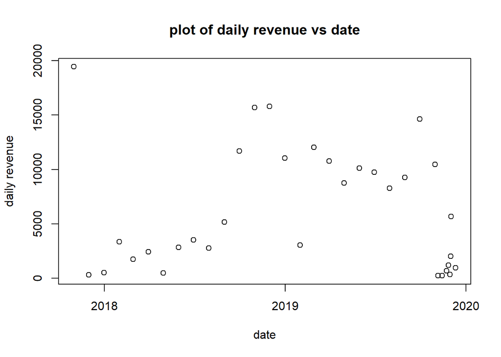

```r
date <- new_data[new_data$usertype == new_accounts[1], ]$balance_date
daily_revenue <- new_data[new_data$usertype == new_accounts[1], ]$daily_revenue
a <- cbind(date, daily_revenue)
plot(new_data[new_data$usertype == new_accounts[1], ]$balance_date,
new_data[new_data$usertype == new_accounts[1], ]$daily_revenue, xlab = "date", ylab = "daily revenue", main = "plot of daily revenue vs date")
```

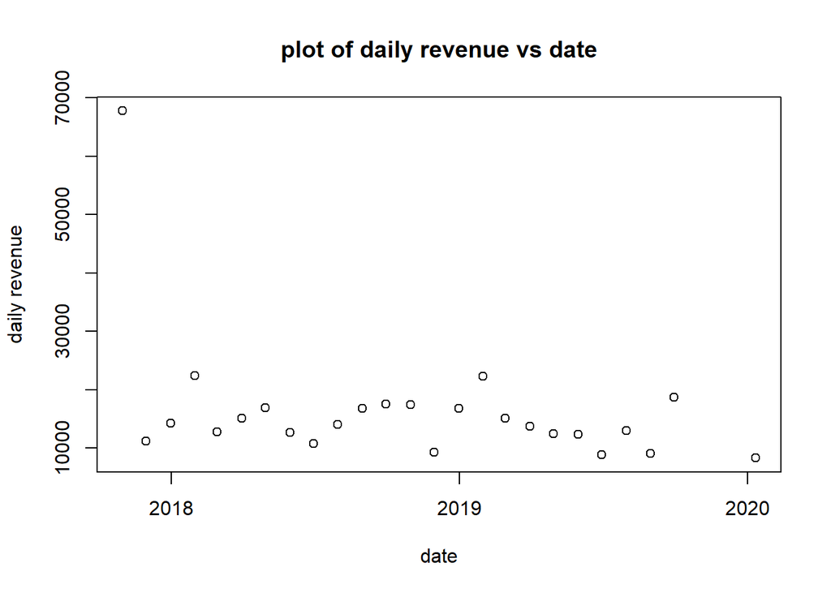

```r
date <- new_data[new_data$usertype == new_accounts[2], ]$balance_date
daily_revenue <- new_data[new_data$usertype == new_accounts[2], ]$daily_revenue
b <- cbind(date, daily_revenue)
plot(new_data[new_data$usertype == new_accounts[2], ]$balance_date,
new_data[new_data$usertype == new_accounts[2], ]$daily_revenue, xlab = "date", ylab = "daily revenue", main = "plot of daily revenue vs date")
```

From the above plot we can see they are Not the uniform distribution. For example the company may have 10 records in one month but 0 at the reset of this year.

## Aggregate by month and take the time series data.

```r
labels <- unique(new_data$Labels)
```

## The table showing the distribution of each label

```r
table(new_data$Labels)
```

```
##
##       A       C       D       E       F       G       H       I       J       K
##    5206    3597     113    3657    2450   17462    3654    4584     407    3696
##       L       M       P       Q       R       S unknown
##    6715   11306    1128    2506    1270     380    1138
```

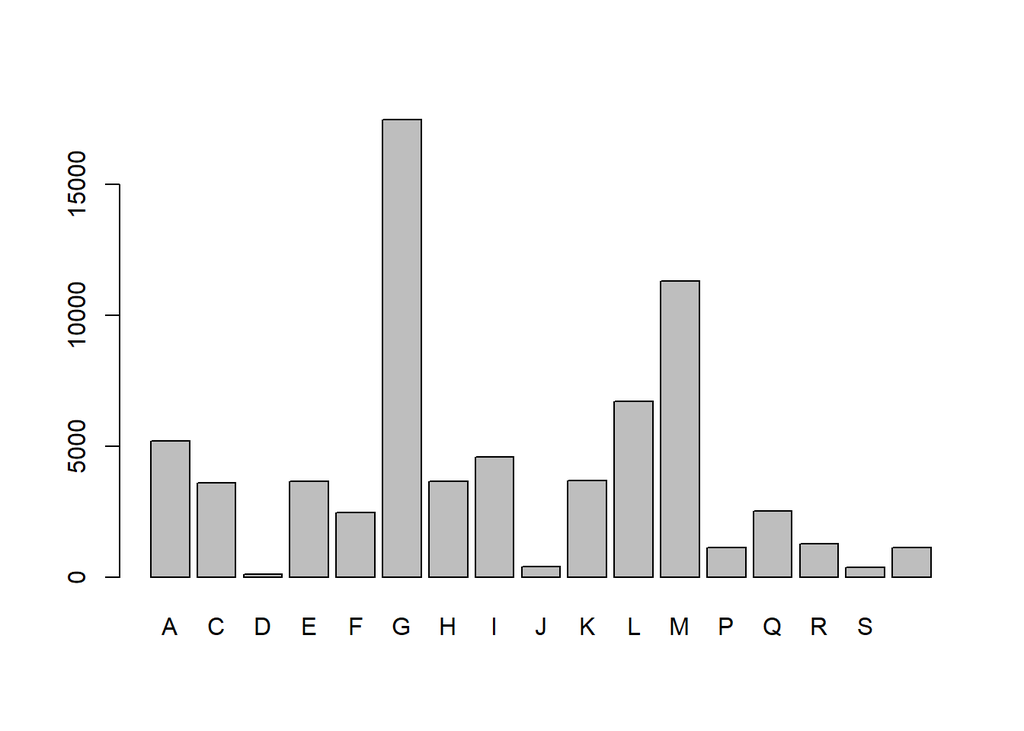

```r
barplot(table(new_data$Labels))
```

## K-means clustering with distance measure equal to Dynamic time warping, input as the cloest 18 months (one and half year).

```
## [1] "M"
```

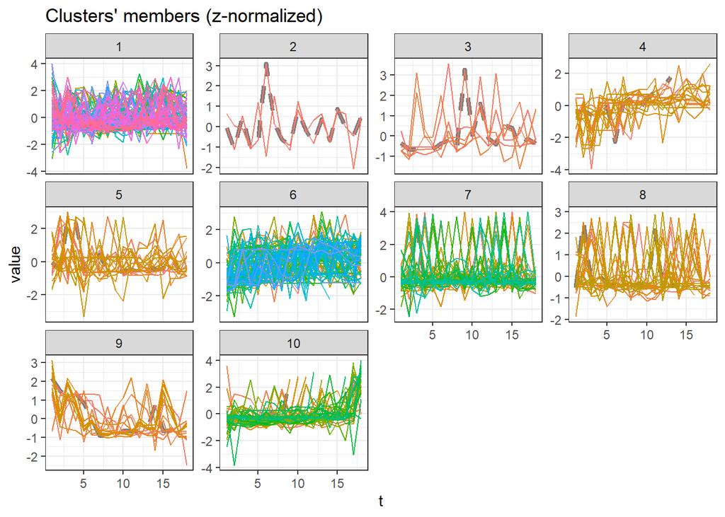

```
##         1         2         3         4         5         6         7         8
## 19686.828  5288.175  4948.299 59904.734  9780.189 30441.402  4557.587 24260.549
##         9        10
## 25555.088  9068.504
## [1] "G"
```

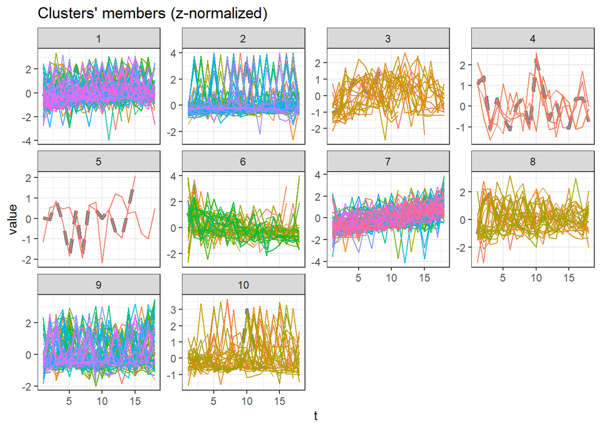

```
##         1         2         3         4         5         6         7         8
## 20989.718  5768.252 13785.149  2086.152  2764.823 16735.564 22981.870 25629.887
##         9        10
## 19262.191 10122.577
## [1] "Q"
```

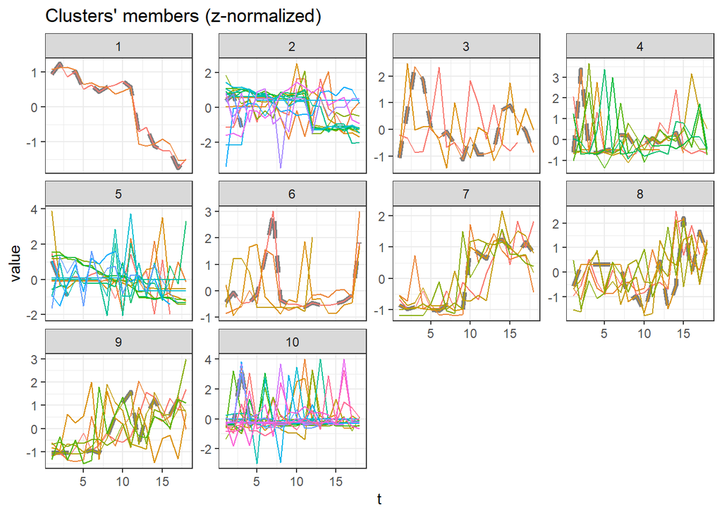

```
##         1         2         3         4         5         6         7         8
## 27176.428 21040.013 19139.039 15347.665 29539.268  7634.144 35049.510 32220.190
##         9        10
## 17233.253 10562.280
## [1] "H"
```

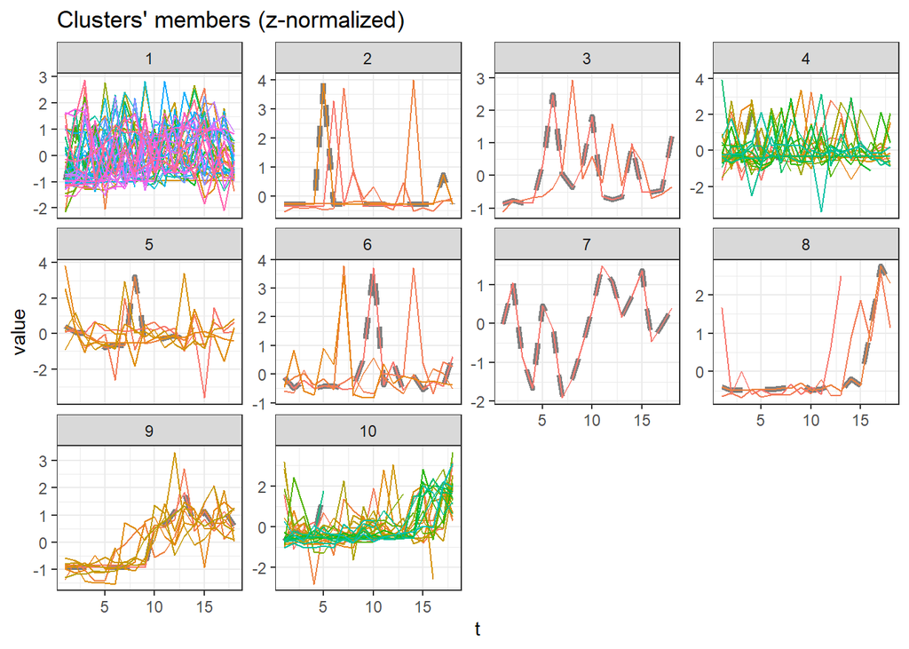

```
##           1           2           3           4           5           6
## 23267.48314 11893.77520 22484.74222 28072.89657  2001.69981  3943.35764
##           7           8           9          10
##    82.20667  6261.69707  7132.60901 14214.84807
## [1] "L"
```

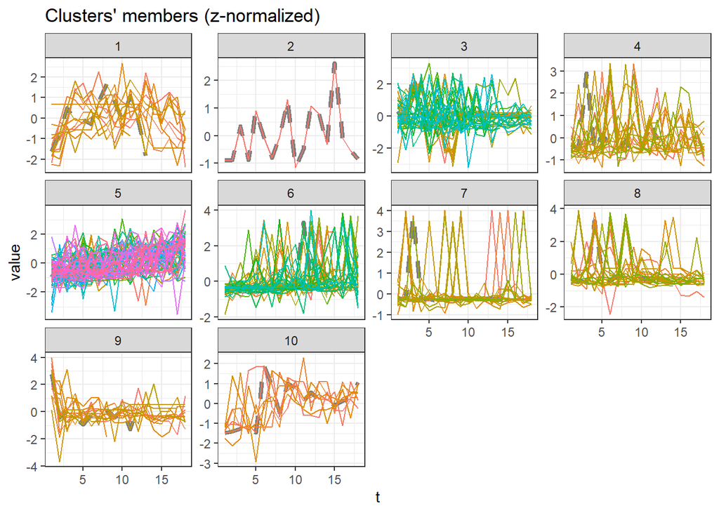

```
##         1         2         3         4         5         6         7         8
## 98617.323 16832.364 26061.281 17632.562 34501.276 13166.646 37385.220 34004.012
##         9        10
##  5101.476 17794.359
## [1] "C"
```

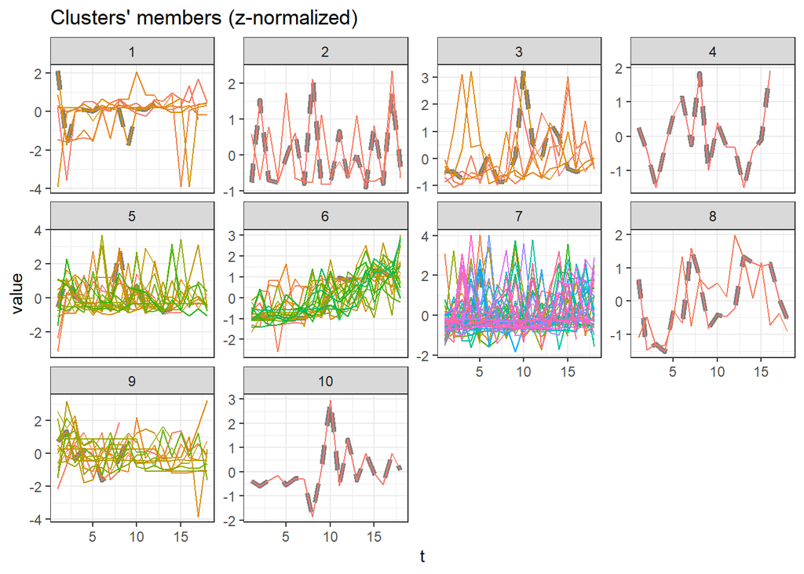

```
##            1            2            3            4            5            6
## 10372.882395  6750.626111  4981.278056     0.305625  7082.024819 39016.593995
##            7            8            9           10
## 22735.935613  5324.747222 15519.578280   588.077222
## [1] "A"
```

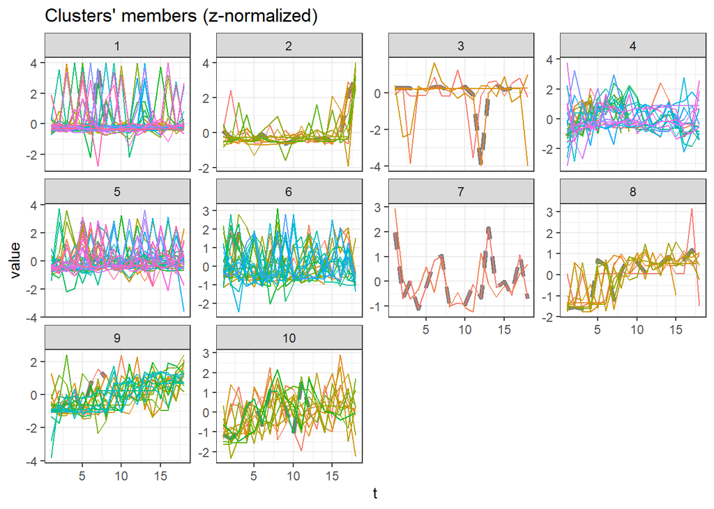

```
##         1         2         3         4         5         6         7         8
## 13065.675 16814.629 16438.585 31024.138 15538.008  8535.189  6608.537 89733.681
##         9        10
## 39286.575 23916.303
## [1] "R"
```

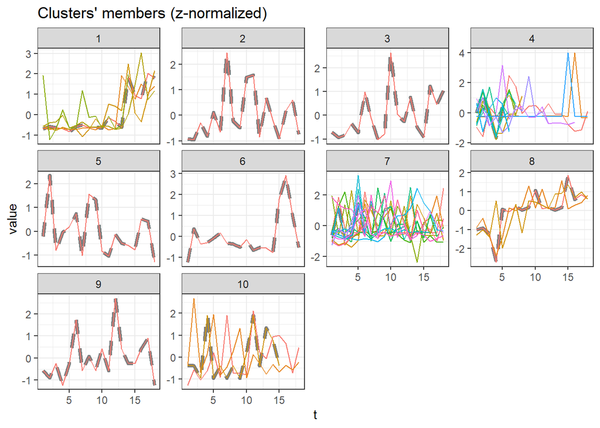

```
##          1          2          3          4          5          6          7
##  20951.716  28229.313  41452.557  17512.205   5180.431   1208.366  15188.755
##          8          9         10
## 143387.691   1631.885  45188.311
## [1] "unknown"
```

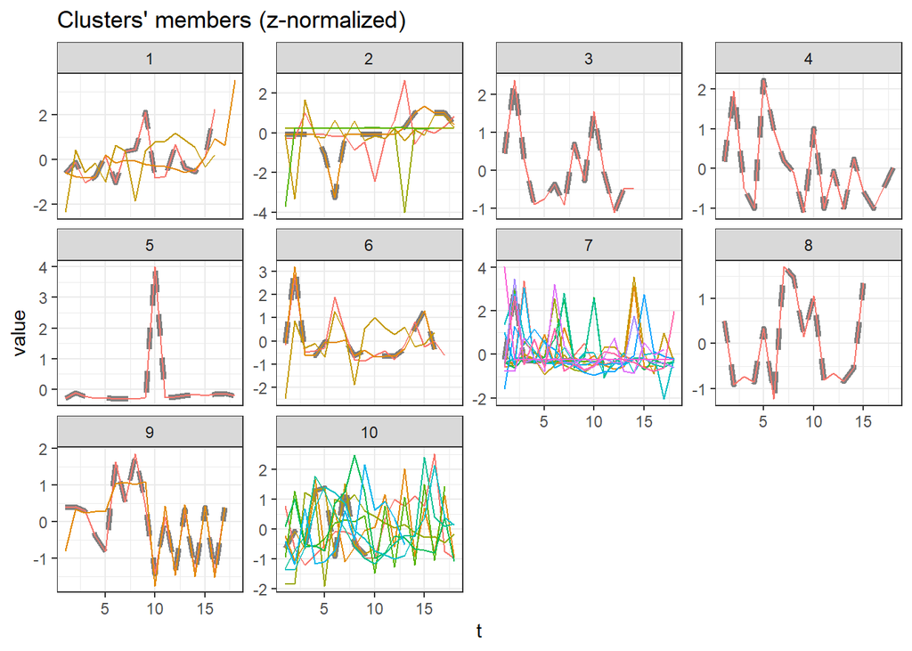

```
##            1            2            3            4            5            6
## 87548.389074     8.181389  2869.645714  5130.918333     8.997222  5748.309216
##            7            8            9           10
##  4293.378140   146.595333  5753.568824  2421.813874
## [1] "K"
```

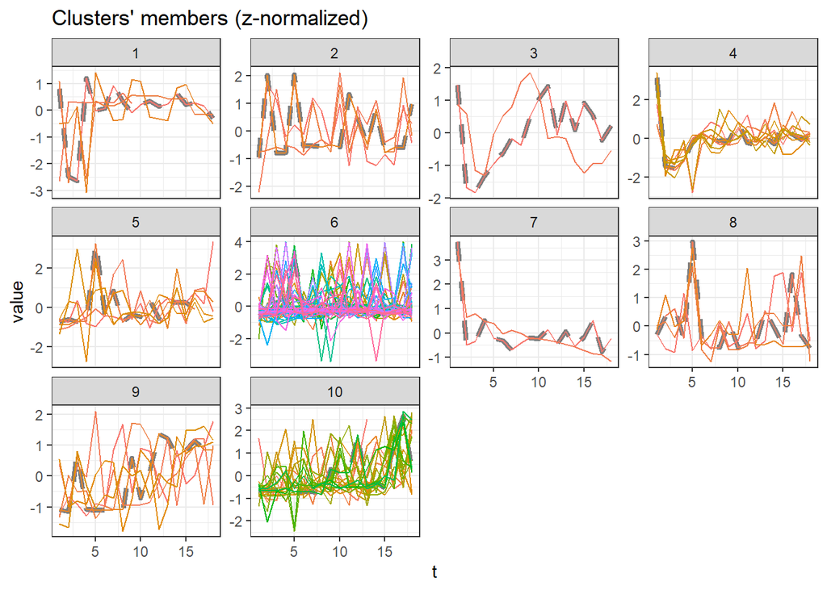

```
##          1          2          3          4          5          6          7
## 93365.0464  1570.6319  6262.4869 29765.1983   412.4196  4464.8252 10752.8933
##          8          9         10
##  2099.2031  7761.6724  5646.1130
## [1] "D"
## [1] "Too less sample for clustering"
## [1] "E"
```

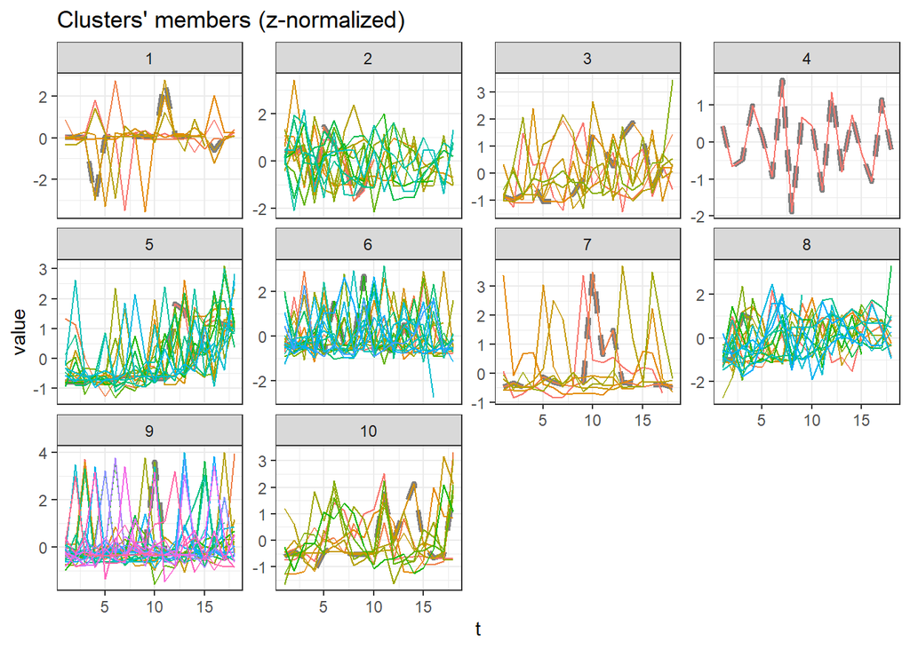

```
##         1         2         3         4         5         6         7         8
##  5295.231  9203.173  1405.210 22969.572  9654.893  3548.261  9227.806 16690.118
##         9        10
## 11720.548 17375.342
## [1] "S"
## [1] "Too less sample for clustering"
## [1] "I"
```

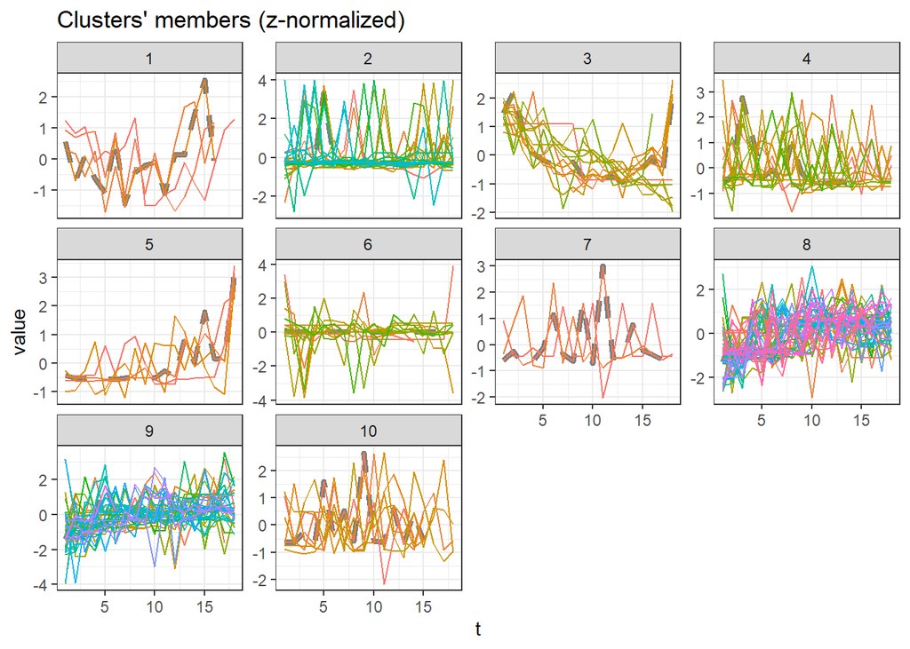

```
##         1         2         3         4         5         6         7         8
##  8050.259 11586.237 80736.046  4891.440 17033.573  6446.549  2960.440 41670.462
##         9        10
## 23057.437  4443.680
## [1] "J"
## [1] "Too less sample for clustering"
## [1] "F"
```

[2 more figures not shown]

```
##          1          2          3          4          5          6          7
## 15754.3630 12441.9658  8100.5117 15318.5872 63380.9881 27877.2624   416.5394
##          8          9         10
##  5995.2374 64714.2555 10850.4410
```

```r
for (label in labels){
  print(label)
  sub_new_data <- as.data.frame(new_data[which(new_data$Labels == label), ])
  new_accounts <- unique(sub_new_data$usertype)
  series <- list()
  final <- data.frame()
  for (element in new_accounts){
    part <- as.data.frame(sub_new_data[sub_new_data$usertype == element, ])
    part_sum <- part%>%
    mutate(month = format(balance_date, "%m"), year = format(balance_date, "%Y"))%>%
    group_by(month, year) %>%
    summarise_at(c("daily_revenue", "revenue_to_date"), sum) %>%
    as.data.frame()
    part_sum <- cbind(part_sum, rep(element, nrow(part_sum)))
    colnames(part_sum) <- c("month","year", "daily_revenue", "revenue_to_date", "accounts_name")
    series <- c(series, list(part_sum$daily_revenue))
    final <- rbind(final, part_sum)
    }
  numbers <- unique(final$accounts)
  length(numbers)
  Date <- as.Date(as.yearmon(paste(final$year, final$month, sep = "-")))
  final <- cbind(Date, final)
  series1 <- list()
  indexs <- which(unlist(lapply(series, FUN = length)) > 18)
  for (index in 1:length(numbers)){
    if (index %in% indexs){
      part <- as.data.frame(sub_new_data[sub_new_data$usertype == levels(numbers)[index], ])
      #new_data[new_data$usertype == numbers[index], ]
      part_filter <- part %>%  arrange(desc(balance_date)) %>% slice(1:18)
      series1 <- c(series1, list(part_filter$daily_revenue))
    }
    else{
      series1 <- c(series1, series[index])
    }
  }
  if(length(series1) < 20){
    print("Too less sample for clustering")
  }
  else{
    pc <- tsclust(series1,preproc = zscore, type = "partitional", k = 10L,
              distance = "dtw_basic", centroid = "pam",
              seed = 3247L, trace = FALSE)
    plot(pc)
    cluster <- tibble(cluster = c(pc@cluster))$cluster
    rev <- sapply(series1, mean)
    sub <- cbind(cluster, rev)
    print(tapply(rev, cluster, mean))
  }
}
```

## Hierarchical clustering with distance measure equal to Dynamic time warping, input as the cloest 18 months for each labels (one and half year).

```
## [1] "M"
```

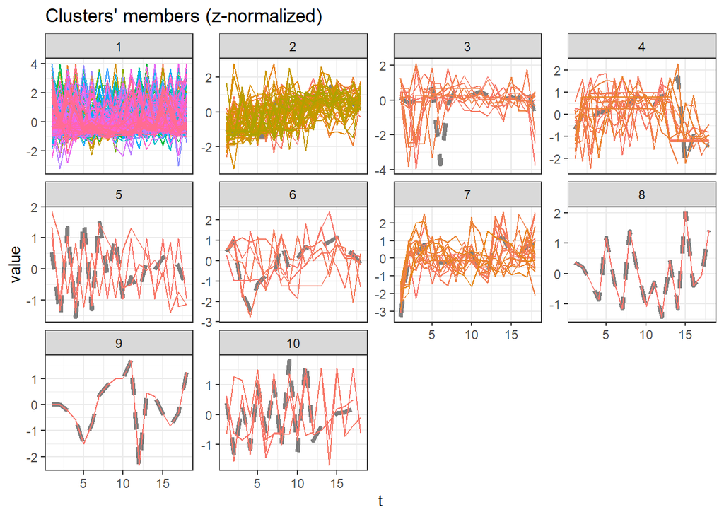

```
##          1          2          3          4          5          6          7
## 15445.4908 44359.5257 52562.0902 14410.8538  3145.3672 12295.7988 10930.9790
##          8          9         10
## 13876.1844  4367.9744   615.3733
## [1] "G"
```

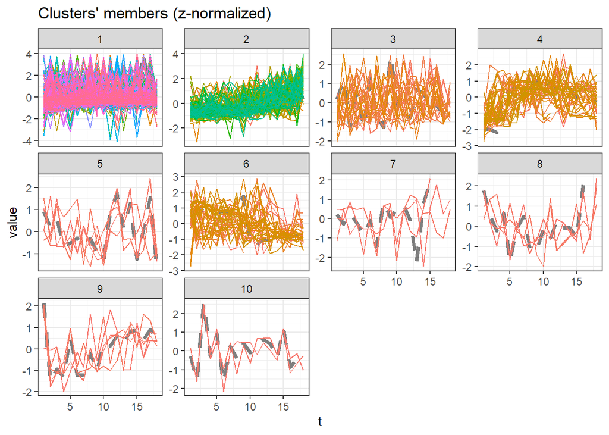

```
##          1          2          3          4          5          6          7
##  12087.791  19751.334  24232.106  11993.944 108454.954  41065.986   3648.286
##          8          9         10
##  20754.344  38382.678   2919.296
## [1] "Q"
```

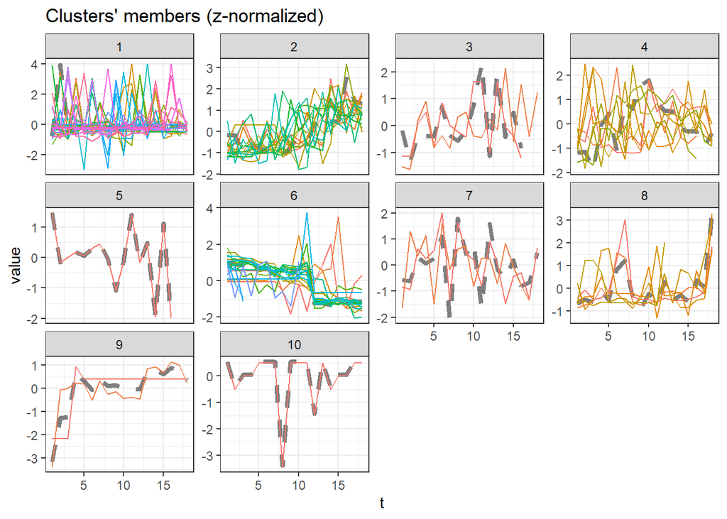

```
##          1          2          3          4          5          6          7
##   3854.225  36359.968   7894.136  35349.977   6970.683  20148.915 103684.687
##          8          9         10
##   5265.971  79391.947    479.170
## [1] "H"
```

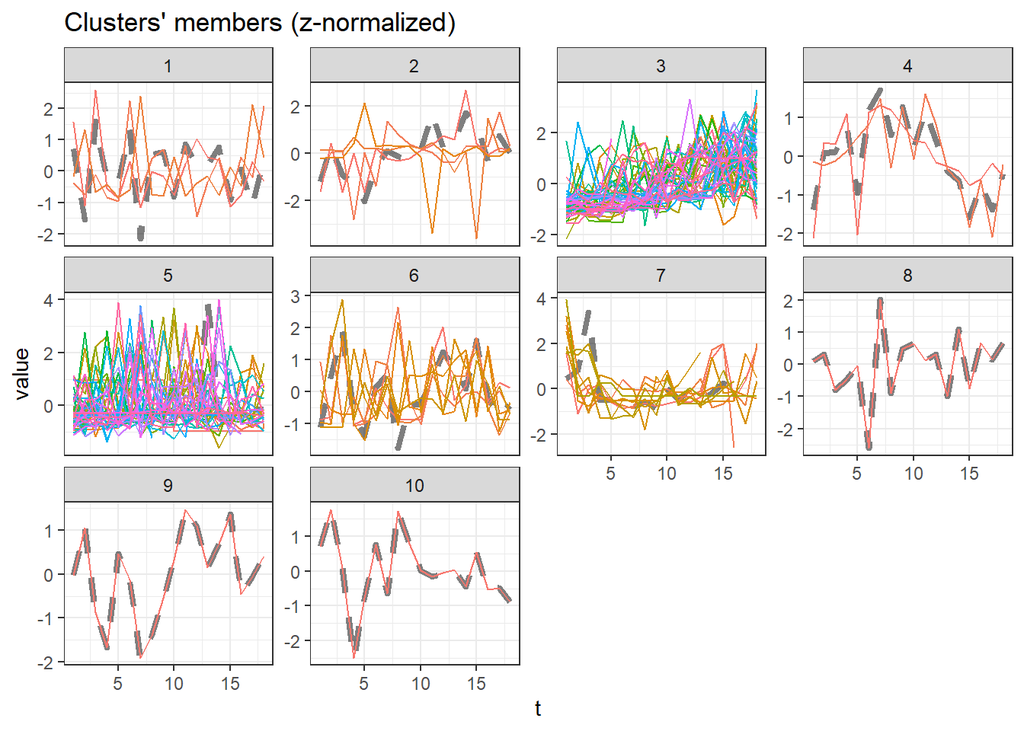

```
##           1           2           3           4           5           6
##   732.75481  8530.19236 11486.73125   260.37722 27857.23547  9265.22921
##           7           8           9          10
## 32426.40926  1547.04167    82.20667  4743.47444
## [1] "L"
```

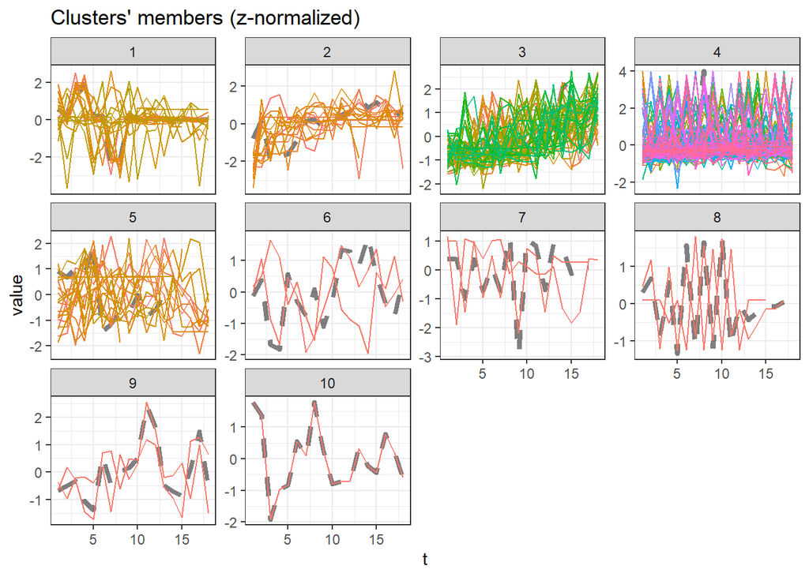

```
##          1          2          3          4          5          6          7
##  30666.346 103538.906  35152.159  20421.786  26757.516  25770.596   3043.083
##          8          9         10
##   1155.127   4804.703  89201.698
## [1] "C"
```

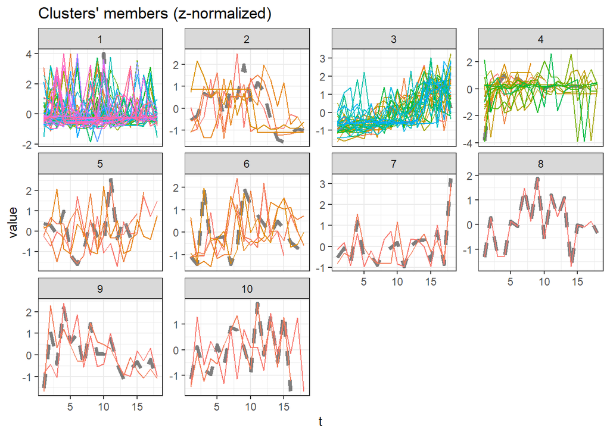

```
##         1         2         3         4         5         6         7         8
## 11241.399  9661.386 34089.476 26150.417 15747.632  8397.620  5927.028  5608.453
##         9        10
## 53633.018  5243.047
## [1] "A"
```

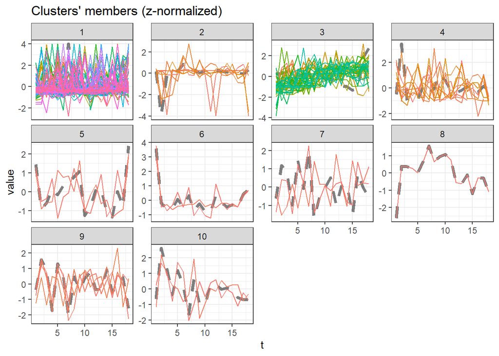

```
##          1          2          3          4          5          6          7
##  14158.884  50206.486  39036.629  16838.145   9538.213   4614.591   6016.552
##          8          9         10
## 224341.807  20230.406   6824.238
## [1] "R"
```

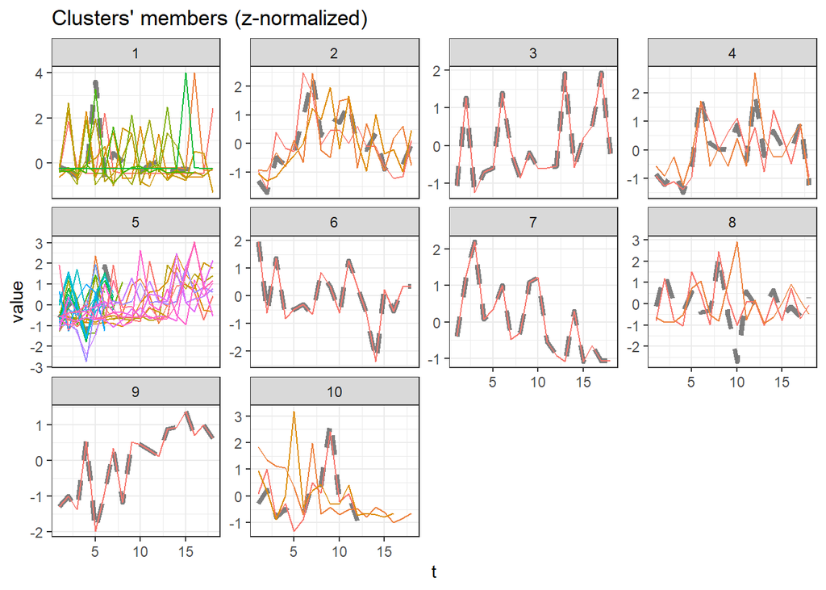

```
##          1          2          3          4          5          6          7
##  11446.069  26937.024   4759.749  10584.879  18425.549  16431.935  53143.889
##          8          9         10
##  25498.146 430285.349  16247.666
## [1] "unknown"
```

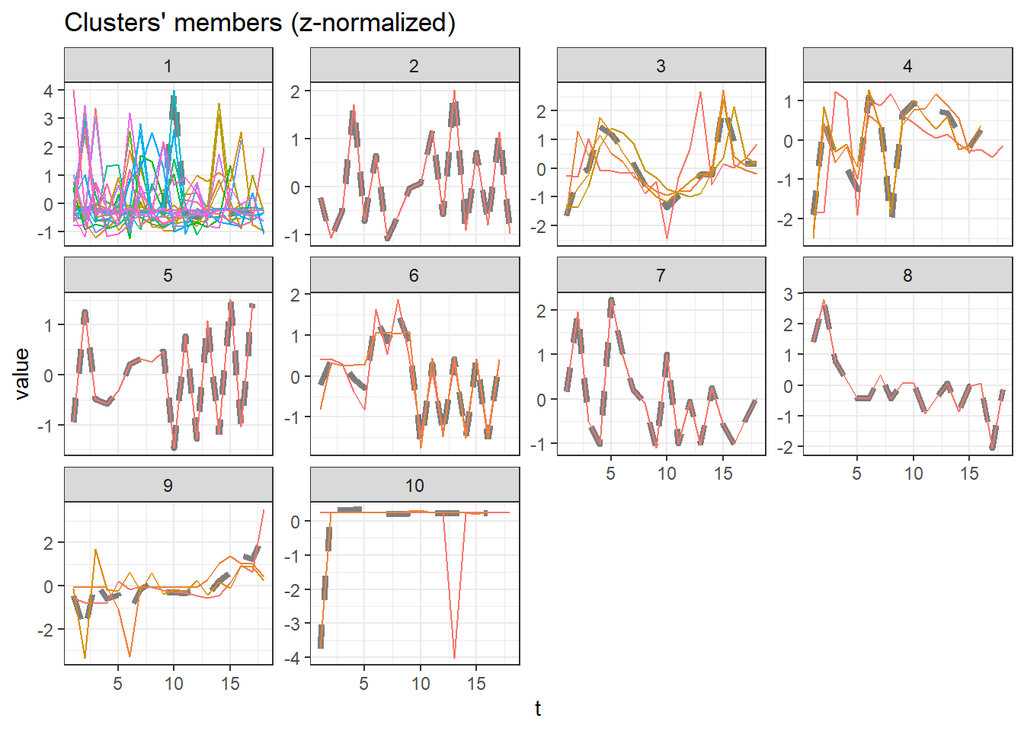

```
##          1          2          3          4          5          6          7
##  1286.8169   646.9261  4301.9546 91969.6295   284.6876  5753.5688  5130.9183
##          8          9         10
## 37899.0350  7481.5398 -8921.0435
## [1] "K"
```

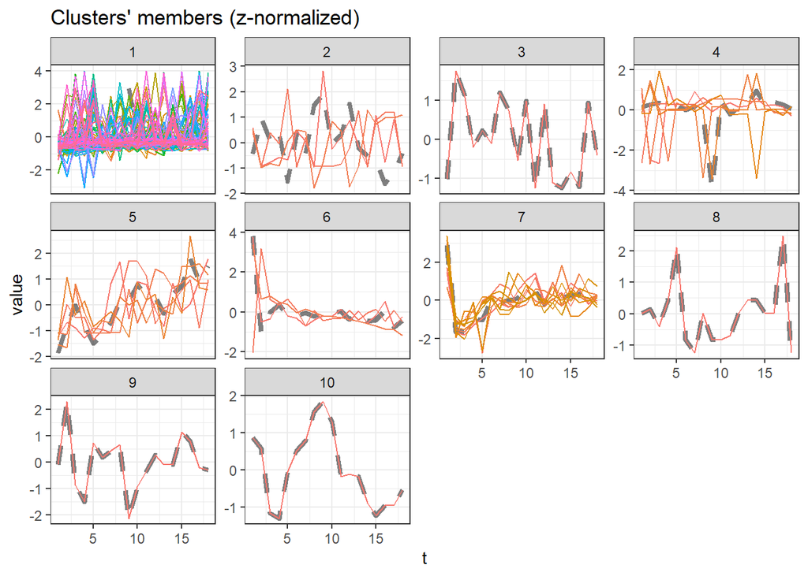

```
##            1            2            3            4            5            6
## 3.441024e+03 1.230913e+04 2.945107e+03 7.573136e+04 2.535579e+03 1.010641e+04
##            7            8            9           10
## 2.804116e+04 1.191667e+02 5.386000e+01 1.955556e-01
## [1] "D"
## [1] "Too less sample for clustering"
## [1] "E"
```

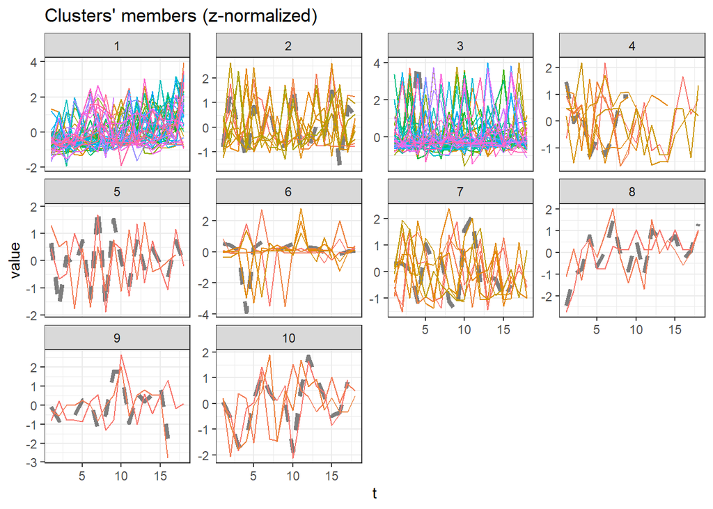

```
##          1          2          3          4          5          6          7
## 16811.2801  3386.2368  6475.4941 10064.1176 11882.3538  5295.2313  2440.0784
##          8          9         10
##  1118.2994   651.3632 23350.0697
## [1] "S"
## [1] "Too less sample for clustering"
## [1] "I"
```

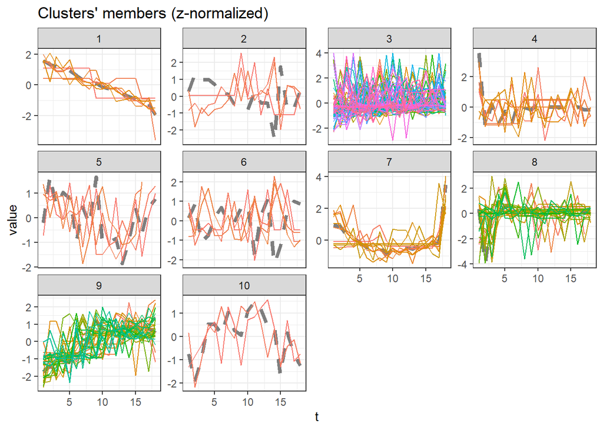

```
##          1          2          3          4          5          6          7
## 12038.8606 11816.2209 10525.0744  3947.7813  8978.3985  1349.1351 90393.5713
##          8          9         10
## 21143.9201 58522.5595   946.3644
## [1] "J"
## [1] "Too less sample for clustering"
## [1] "F"
```

[2 more figures not shown]

```
##          1          2          3          4          5          6          7
##   416.5394 39181.6102 98566.6424  3281.3210 35291.7028  9386.8122 19009.2606
##          8          9         10
##   360.2417  1879.4706 41385.0652
```

```r
for (label in labels){
  print(label)
  sub_new_data <- as.data.frame(new_data[which(new_data$Labels == label), ])
  new_accounts <- unique(sub_new_data$usertype)
  series <- list()
  final <- data.frame()
  for (element in new_accounts){
    part <- as.data.frame(sub_new_data[sub_new_data$usertype == element, ])
    part_sum <- part%>%
    mutate(month = format(balance_date, "%m"), year = format(balance_date, "%Y"))%>%
    group_by(month, year) %>%
    summarise_at(c("daily_revenue", "revenue_to_date"), sum) %>%
    as.data.frame()
    part_sum <- cbind(part_sum, rep(element, nrow(part_sum)))
    colnames(part_sum) <- c("month","year", "daily_revenue", "revenue_to_date", "accounts_name")
    series <- c(series, list(part_sum$daily_revenue))
    final <- rbind(final, part_sum)
    }
  numbers <- unique(final$accounts)
  length(numbers)
  Date <- as.Date(as.yearmon(paste(final$year, final$month, sep = "-")))
  final <- cbind(Date, final)
  series1 <- list()
  indexs <- which(unlist(lapply(series, FUN = length)) > 18)
  for (index in 1:length(numbers)){
    if (index %in% indexs){
      part <- as.data.frame(sub_new_data[sub_new_data$usertype == levels(numbers)[index], ])
      #new_data[new_data$usertype == numbers[index], ]
      part_filter <- part %>%  arrange(desc(balance_date)) %>% slice(1:18)
      series1 <- c(series1, list(part_filter$daily_revenue))
    }
    else{
      series1 <- c(series1, series[index])
    }
  }
  if(length(series1) < 20){
    print("Too less sample for clustering")
  }
  else{
    hc_sbd <- tsclust(series1, type = "h", k = 10L,preproc = zscore, seed = 3247L, distance = "dtw_basic", centroid = shape_extraction, control = hierarchical_control(method = "average"), trace = FALSE)
    plot(hc_sbd, type = "sc")
    cluster <- tibble(cluster = c(hc_sbd@cluster))$cluster
    rev <- sapply(series1, mean)
    sub <- cbind(cluster, rev)
    print(tapply(rev, cluster, mean))
  }
}
```